# Zadanie4

Dorota Łępicka, Katarzyna Zdon, Mateusz Kałamarz

19 kwietnia 2017

# Cel zadania

Na podstawie poprzednich zadań opracowujemy podział strategii uczniów na kilka nazwanych i zdefiniowanych segmentów, aby następnie porównać wybrane kraje pod kątem występowania poszczególnych strategii.

# Wnioski

Ostatecznie na podstawie podsumowania strategii z rodziału 4. wyciągamy wnioski odnośnie dominujących strategii w poszczególnych krajach.

# 1. Wybór krajów do analizy

W dalszej analizie ograniczamy zbiór danych do poniższych krajów:

- Polska
- Korea Południowa
- Finlandia
- Grecja
- Brazylia
- Rosja
- Niemcy

Decydujemy się na taki wybór, ponieważ naszym zdaniem zapewnia on dużą różnorodność wyników.

# 2. Wstępna analiza danych

Aby przygotować dane do dalszej analizy wybieramy tylko te obserwacje, dla których nie występują braki danych. Dodatkowo usuwamy obserwacje dla osób, które zrezygnowały w trakcie testu. Są to dla nas takie osoby, które na zadanie w ostatnim rozwiązywanym przez siebie klastrze poświeciły więcej niż godzinę. Ponieważ całkowity czas testu wynosi dwie godziny, zatem również nie rozpatrujemy osób rozwiązujących w sumie test ponad dwie godziny.

Ostatecznie rozkład danych wygląda nastepująco:

|  | BRA | DEU | FIN | GRC | KOR | POL | RUS |
| --- | --- | --- | --- | --- | --- | --- | --- |
| liczba uczniów | 16145 | 4456 | 4107 | 3847 | 3880 | 4475 | 4131 |

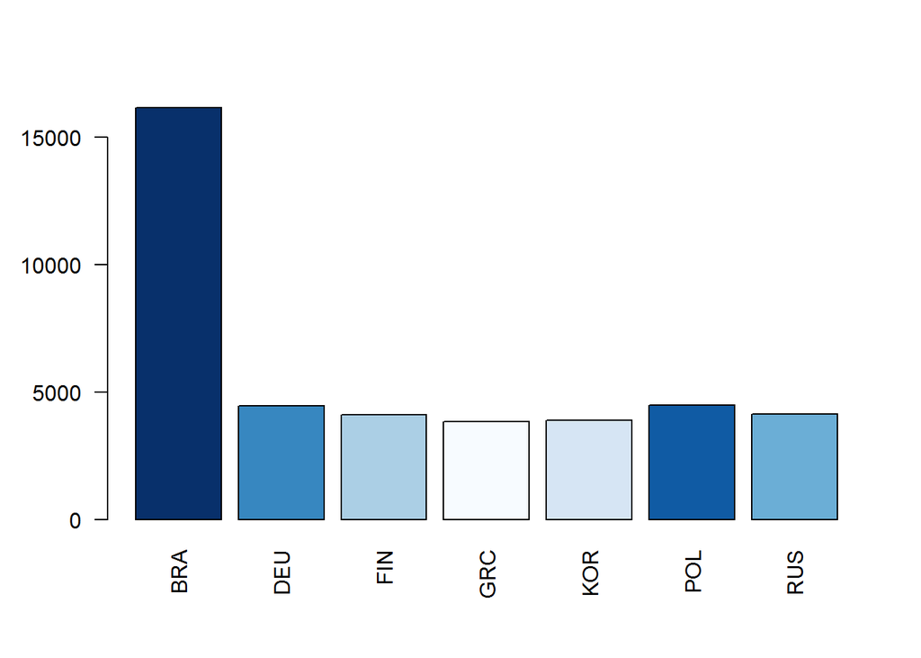

Dodatkowo oceniamy rozkład pytań w każdym klastrze:

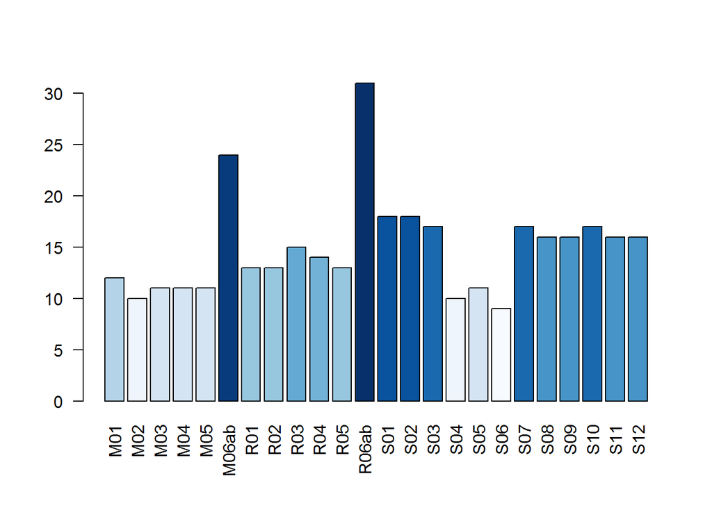

Można wyraźnie zauwazyć, że w klastrach oznaczonych symbolem `ab` wystepuje znacznie większa liczba pytań. Są to klastry `podwójne`.

# 3. Strategie uczestników

Rozważamy następujące strategie:

1. Gapik - uczniownie poświęcają dużo czasu na początku testu, a później szybko rozwiązują zadania
2. Śpioch - uczniownie źle rozplanowują swój czas na zadania
3. Ważniak - uczniownie poświęcają dużo czasu na zadania które potrafią rozwiązać, natomiast mało na zadania których nie umieją zrobić
4. Zgrywus - uczniownie chcą szybko skończyć test niezależnie od poprawności wynikóW
5. Pracuś - uczniownie przygotowywują się do testu

[figure not shown]

### 3.1 Strategia I (Gapik)

Uczniownie poświęcają dużo czasu na początku testu, a później szybko rozwiązują zadania. Poszukujemy osób, które w pierwszym klastrze rozwiązują zadania wolniej niż mediana innych osób, jednocześnie w 4 klastrze rozwiązując je szybciej.

W każdym z wybranych przez nas krajów procentowy udział tej strategii wynosi:

|  | BRA | DEU | FIN | GRC | KOR | POL | RUS |
| --- | --- | --- | --- | --- | --- | --- | --- |
| procent uczniów w kraju | 31.88 | 8.71 | 5.79 | 19.68 | 3.25 | 10.61 | 21.35 |

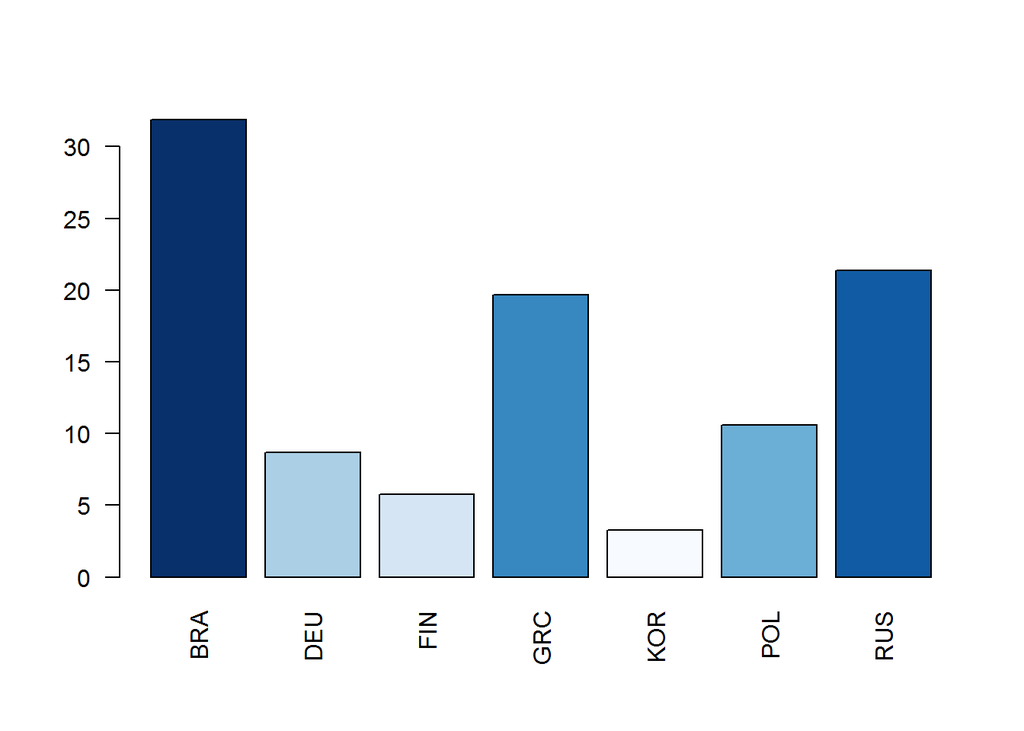

### 3.2 Strategia II (Śpioch)

Uczniownie źle rozplanowują swój czas na zadania.

W tej grupie znajdą się uczniowie, którzy rozwiązali z 4 klastra mniej niż mediana liczby zadań rozwiązanych przez wszystkich.

Ponieważ mediana nierozwiązanych zadań wynosi 0, zatem za uczniów którzy nie rozplanowują czasu uważamy tych, którym nie udaje się dojść do końca zaplanowanych zadań.

Procentowo dla wybranych przez nas krajów:

|  | BRA | DEU | FIN | GRC | KOR | POL | RUS |
| --- | --- | --- | --- | --- | --- | --- | --- |
| procent uczniów w kraju | 77.36 | 42.03 | 34.67 | 47.78 | 35.49 | 41.25 | 50.18 |

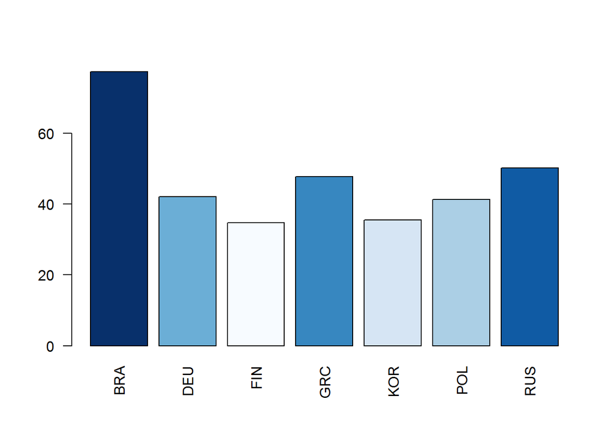

### 3.3 Strategia III (Ważniak)

Uczniownie poświęcają dużo czasu na zadania które potrafią rozwiązać, natomiast mało na zadania których nie umieją zrobić. W obrębie studenta patrzymy na sumaryczny czas zadań, które rozwiązał poprawnie i sumaryczny czas zadań rozwiązanych błędnie.

Ogólnie mediana dla różnicy poświęconego czasu dla zadań rozwiązanych poprawnie i niepoprawnie jest ujemna, zatem uczniowie poświęcają łącznie więcej czasu na zadania których nie potrafią zrobić.

Uczniów którzy poświęcają dużo czasu na zadania, które potrafią zrobić możemy identyfikować po tym, że ich łączny czas jest powyżej 3 kwantyla.

Odsetek uczniów poświęcających więcej czasu na zadania które rozwiązują poprawnie (potrafią zrobić):

|  | BRA | DEU | FIN | GRC | KOR | POL | RUS |
| --- | --- | --- | --- | --- | --- | --- | --- |
| procent uczniów w kraju | 8.11 | 36.85 | 39.23 | 22.85 | 27.73 | 30.91 | 26.48 |

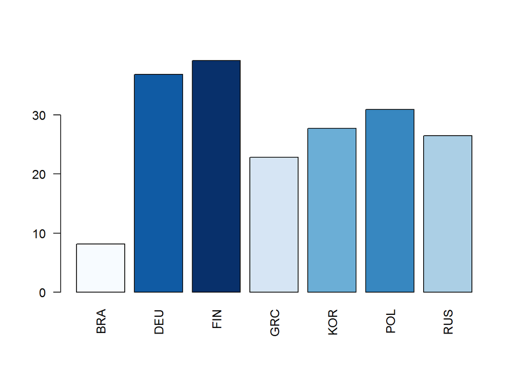

### 3.4 Strategia IV (Zgrywus)

Uczniowie chcą szybko skończyć test niezależnie od wyniku.

W tej grupie chcemy zidentyfikować tych uczniów, którzy ‘przeklikują’ test i nie są zmotywowani do uzyskania dobrego wyniku.

Dla wybranych krajów uzyskujemy następujący rozkład (w procentach):

|  | BRA | DEU | FIN | GRC | KOR | POL | RUS |
| --- | --- | --- | --- | --- | --- | --- | --- |
| procent uczniów w kraju | 17.93 | 16.32 | 17.73 | 16.97 | 26.6 | 13.52 | 9.83 |

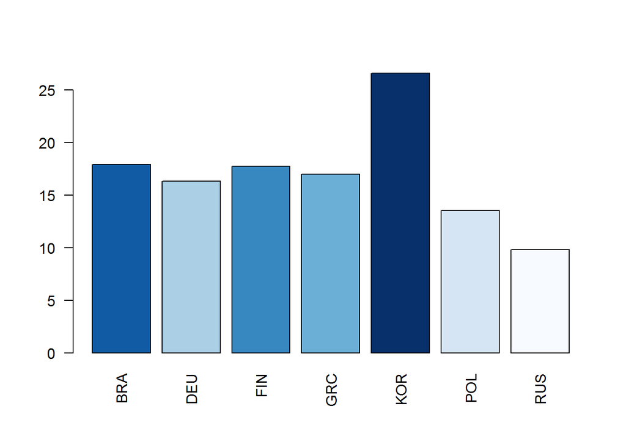

### 3.5 Strategia V (Pracuś)

Uczniownie przygotowują się do testu.

W tej grupie znajdziemy uczniów, którzy mają mało akcji, krótki czas rozwiązywania zadań i dużo poprawnych odpowiedzi.

|  | BRA | DEU | FIN | GRC | KOR | POL | RUS |
| --- | --- | --- | --- | --- | --- | --- | --- |
| procent uczniów w kraju | 11.45 | 25.96 | 7.82 | 5.9 | 83.25 | 27.17 | 21.37 |

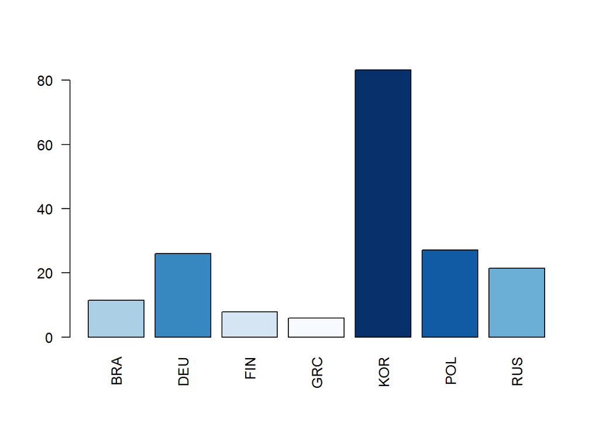

# 4. Podsumowanie strategii

|  | Gapik | Spioch | Wazniak | Zgrywus | Pracus | Suma |
| --- | --- | --- | --- | --- | --- | --- |
| BRA | 31.88 | 77.36 | 8.11 | 17.93 | 11.45 | 146.73 |
| DEU | 8.71 | 42.03 | 36.85 | 16.32 | 25.96 | 129.87 |
| FIN | 5.79 | 34.67 | 39.23 | 17.73 | 7.82 | 105.24 |
| GRC | 19.68 | 47.78 | 22.85 | 16.97 | 5.90 | 113.18 |
| KOR | 3.25 | 35.49 | 27.73 | 26.60 | 83.25 | 176.32 |
| POL | 10.61 | 41.25 | 30.91 | 13.52 | 27.17 | 123.46 |
| RUS | 21.35 | 50.18 | 26.48 | 9.83 | 21.37 | 129.21 |

Zauważamy, że zdefiniowane przez nas strategie nie wykluczają się, ani nie są rozłączne. Zatem mogą wystepować uczniowie, którzy stosują kilka strategii jednocześnie.

# 5. Nieokreślona strategia

Występują również studenci, którym nie przypisalismy żadej strategii.

|  | BRA | DEU | FIN | GRC | KOR | POL | RUS |
| --- | --- | --- | --- | --- | --- | --- | --- |
| procent uczniów w kraju | 13.32 | 18.69 | 24.2 | 25.84 | 4.79 | 22.35 | 21.96 |

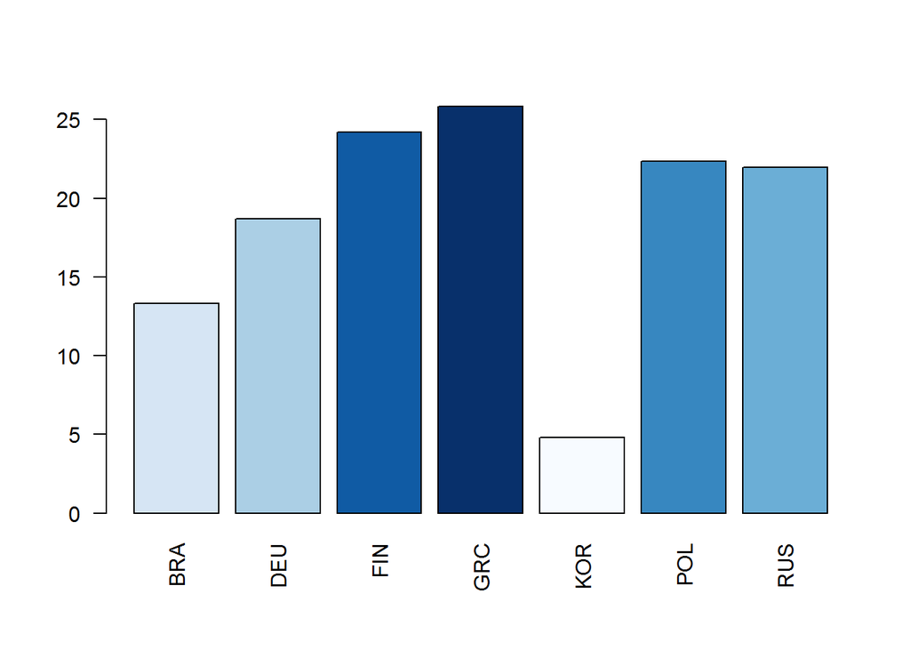

# 6. SYNTAX

Wczytanie potrzebnych pakietów i danych

```r
memory.size(20000)

library(dplyr)
library(stringi)
library(knitr)

load("dane_06_06.Rda")
```

Przygotowanie danych:

```r
dane_popr <- dane %>% filter(!is.na(timing) & !is.na(n.actions) & !is.na(result))

dane_popr$timing<-dane_popr$timing/1000
```

Usuwamy z danych osoby, które zrezygnowały w trakcie testu. Są to osoby, które w zadaniu z ostatniego rozwiązywanego przez siebie klastra poświęciły więcej niż godzinę na jego rozwiązanie.

```r
zrezygnowali <- dane_popr %>% select(CNTSTUID,  position, timing)%>%
   filter(timing>3600) %>%
   group_by(CNTSTUID) %>%
   mutate(maksymalny=max(as.numeric(position)))

zrezygnowali <- zrezygnowali %>% filter( maksymalny==position )

dane_popr <- dane_popr %>% filter(!(CNTSTUID %in% zrezygnowali$CNTSTUID))
```

Również usuwamy osoby, których czas rozwiązywania przekracza 2h. Ponieważ cały test trwał łącznie 2h zatem każda osoba z sumarycznym czasem ponad tę wartość nie powinna znaleźć się w danych. Bierzemy pod uwagę 1-minutowy błąd pomiaru.

```r
dane_ponad2h <- dane_popr %>% group_by(CNTSTUID, CNT)%>%summarise(czas=sum(timing))
dane_ponad2h <- dane_ponad2h %>% filter(czas>121*60)
dane_popr <- dane_popr%>% filter(!(CNTSTUID %in% dane_ponad2h$CNTSTUID))
```

Wybór krajów do analizy:

```r
dane_kraje <- dane_popr %>% filter(stri_trim(CNT) %in% c("POL","BRA","FIN","DEU","GRC","KOR","RUS"))
```

Analiza:

Ilość osób z poszczególnych krajów:

```r
dane_licznosci<-dane_kraje %>% select(CNT, CNTSTUID)

dane_licznosci<-unique(dane_licznosci)

(ile_osob <- table(dane_licznosci$CNT))
```

Ilość osób rozwiązująca zadania na kolejnych pozycjach:

```r
czy_1<-aggregate(position~CNTSTUID, data=unique(dane_kraje[,c("CNTSTUID","position")]),function(x) {1 %in% x})
s1 <- sum(czy_1[,2])

czy_2<-aggregate(position~CNTSTUID, data=unique(dane_kraje[,c("CNTSTUID","position")]),function(x) {all(c(1,2) %in% x)})
s2 <- sum(czy_2[,2])

czy_3<-aggregate(position~CNTSTUID, data=unique(dane_kraje[,c("CNTSTUID","position")]),function(x) {all(c(1,2,3) %in% x)})
s3 <- sum(czy_3[,2])

czy_4<-aggregate(position~CNTSTUID, data=unique(dane_kraje[,c("CNTSTUID","position")]),function(x) {all(c(1,2,3,4) %in% x)})
s4 <- sum(czy_4[,2])
```

Wykres ilości pytań dla każdego klastra:

```r
dane_kraje_gr<-aggregate(item~CLVS, data=unique(dane_kraje[,c("item","CLVS")]),FUN = length)
colors<-colorRampPalette(RColorBrewer::brewer.pal(9,"Blues"))(24)
barplot(dane_kraje_gr$item,names.arg = dane_kraje_gr$CLVS, las=2, col=colors[rank(dane_kraje_gr$item)])
```

Strategia I

```r
CNT_4<-czy_4$CNTSTUID[czy_4$position]
dane1234<-dane_kraje %>% filter(CNTSTUID %in% CNT_4)

dane1234_unique<-dane1234 %>% select(CNTSTUID, position, CLVS) %>% filter(position %in% c(1,4)) %>% unique()
dane1234_unique<-tidyr::spread(dane1234_unique,position,CLVS)

sum_1<-dane1234 %>% filter(position == 1) %>% group_by(CNTSTUID, CLVS) %>% summarise(suma=sum(timing))

sum_4<-dane1234 %>% filter(position == 4) %>% group_by(CNTSTUID, CLVS) %>% summarise(suma=sum(timing))

med_1<- sum_1 %>% group_by(CLVS) %>% summarise(mediana=median(suma))

med_4<- sum_4 %>% group_by(CLVS) %>% summarise(mediana=median(suma))

CNTSTUID_1<-(merge(sum_1,med_1,by = "CLVS") %>% filter(suma>mediana))$CNTSTUID
CNTSTUID_4<-(merge(sum_4,med_4,by = "CLVS") %>% filter(suma<mediana))$CNTSTUID
CNTSTUID_str1<-intersect(CNTSTUID_1,CNTSTUID_4)

length(CNTSTUID_str1)

dane_str1<-unique(dane1234[dane1234$CNTSTUID %in% CNTSTUID_str1,c("CNT", "CNTSTUID")])
tab_str1<-table(dane_str1$CNT)
(stat_str1<-tab_str1/ile_osob*100)
```

Strategia II

```r
dane2 <- dane_popr %>%filter(position==4)%>%group_by(CNTSTUID, CLVS ) %>%
  summarise(ile_z_4=n())

dane_pon_4 <- dane_popr %>% group_by(CNTSTUID ) %>%
  summarise(max_poz=max(position))

dane_pon_4 <- dane_pon_4 %>% filter(max_poz<4)

dane2_gr<-aggregate(item~CLVS, data=unique(dane_popr[,c("item","CLVS")]),FUN = length)

dane2_gr[dane2_gr$CLVS=="M06ab","item"] <- 12

dane2_gr[dane2_gr$CLVS=="R06ab","item"] <- 16

dane2<- merge(dane2, dane2_gr)

dane2 <- dane2 %>% mutate(roznica=item-ile_z_4)

tab<-table(dane2$roznica)
tab[nrow(tab)] <- tab[nrow(tab)]+nrow(dane_pon_4)
med <- median(rep.int(0:(nrow(tab)-1),times=as.vector(tab)))

powolni <- dane2 %>% filter(roznica>med) %>% select(CNTSTUID)

dane3 <- dane_kraje%>% filter(CNTSTUID %in% c(powolni$CNTSTUID, dane_pon_4$CNTSTUID))
dane4 <- unique(dane3[,c("CNT","CNTSTUID")])

(stat_str2<-table(dane4$CNT)/ile_osob*100)
```

Strategia III

```r
dane_kraje1 <- dane_popr %>% group_by(CNTSTUID,CNT, result) %>% summarise(czas=sum(timing))

dane_kraje2 <- tidyr::spread(dane_kraje1, result, czas)

colnames(dane_kraje2)<-c("CNTSTUID","CNT","no","yes")

dane_kraje2[is.na(dane_kraje2$yes),"yes"] <- 0
dane_kraje2[is.na(dane_kraje2$no),"no"] <- 0

dane_kraje2 <- dane_kraje2 %>% mutate(roznica=yes-no)

quantile(dane_kraje2$roznica)

q3<-quantile(dane_kraje2$roznica)[4]

dane_kraje3<-dane_kraje2 %>% filter(roznica>q3  )

unikalne<-unique(dane_kraje$CNTSTUID)

dane_kraje3<-dane_kraje3 %>% filter(CNTSTUID %in% unikalne)

ile_osob <- table(dane_licznosci$CNT)

(stat_str3<-table(dane_kraje3$CNT)/ile_osob*100)
```

Strategia IV

```r
dane21<- dane_popr%>%group_by(CNT,CNTSTUID) %>% summarise(czas=sum(timing))

quantile(dane21$czas)

q1<-quantile(dane21$czas)[2]

dane22<- dane21 %>% filter(czas < q1)

dane22<- dane_kraje%>% filter(CNTSTUID %in% dane22$CNTSTUID)

dane23 <- dane22 %>% group_by(CNT,CNTSTUID) %>% summarise(ile=mean(result))

dane23 <- dane23 %>% filter(ile<0.5)

(stat_str4<-table(dane23$CNT)/ile_osob*100)
```

Strategia V

```r
dane31<-dane_popr %>% group_by(CNTSTUID, CNT) %>%
    summarise(sr_akcji=mean(n.actions), sr_czas=mean(timing), wynik=sum(result*weights))

med1 <- quantile(dane31$sr_akcji)[3]
med2 <- quantile(dane31$sr_czas)[3]
med3 <- quantile(dane31$wynik)[3]

dane32<-dane31%>% filter(sr_akcji <=med1 & sr_czas<=med2 & wynik>=med3 )

dane33 <- dane32 %>% filter(stri_trim(CNT) %in% c("POL","BRA","FIN","DEU","GRC","KOR","RUS"))

(stat_str5<-table(dane33$CNT)/ile_osob*100)
```

Podsumowanie strategi

```r
stat_sum<-stat_str1+stat_str2+stat_str3+stat_str4+stat_str5
```

```r
kable(data.frame(Strategia1=as.vector(stat_str1),
         Strategia2=as.vector(stat_str2),
         Strategia3=as.vector(stat_str3),
         Strategia4=as.vector(stat_str4),
         Strategia5=as.vector(stat_str5),
         Suma=as.vector(stat_sum), stringsAsFactors = FALSE, row.names = names(stat_str1)))
```

Nieokreślona strategia:

Tabele dla wszystkich powyższych strategii były zapisywane, zatem możemy z nich skorzystać:

```r
load("CNTSTUID_str1.Rda")
load("CNTSTUID_str2.Rda")
load("CNTSTUID_str3.Rda")
load("CNTSTUID_str4.Rda")
load("CNTSTUID_str5.Rda")
```

```r
CNT_wszystkie<-unique(dane_kraje$CNTSTUID)

CNTSTUID_nieznane<-setdiff(CNT_wszystkie,unique(c(CNTSTUID_str1,CNTSTUID_str2,CNTSTUID_str3,CNTSTUID_str4,CNTSTUID_str5)))

dane_nieznane<-dane_kraje %>% filter(CNTSTUID %in% CNTSTUID_nieznane)
dane_nieznane<-unique(dane_nieznane[,c("CNT","CNTSTUID")])
tab_nieznane<-table(dane_nieznane$CNT)
(stat_nieznane<-tab_nieznane/ile_osob*100)
```

Tworzenie szerokiej postaci tabeli:

```r
kable(data.frame(spread(tab_nieznane, CNT, ile), row.names = "procent uczniów w kraju"))
```

Barplot dla liczności:

```r
colors <- colorRampPalette(RColorBrewer::brewer.pal(9,"Blues"))(7)
barplot(tab_nieznane[[2]],names.arg = tab_nieznane[[1]], las=2, col=colors[rank(tab_nieznane[[2]])])
```